# Data Visualization: `ggplot` part 5

## Learning Goals

*At the end of this exercise, you will be able to:*  
1. Build histograms and density plots. 2. Adjust colors using R’s built-in color options.  
3. Create new categories with `case_when()` and use those categories to build plots.  
4. Build line plots.

## Resources

- [ggplot2 cheatsheet](https://www.rstudio.com/wp-content/uploads/2015/03/ggplot2-cheatsheet.pdf)
- [R for Data Science](https://r4ds.had.co.nz/)
- [R Cookbook](http://www.cookbook-r.com/)
- [`ggplot` themes](https://ggplot2.tidyverse.org/reference/ggtheme.html)
- [Rebecca Barter `ggplot` Tutorial](http://www.rebeccabarter.com/blog/2017-11-17-ggplot2_tutorial/)
- [R Color Brewer](http://colorbrewer2.org/#type=sequential&scheme=BuGn&n=3)

## Load the libraries

```r
library(tidyverse)
library(janitor)
```

```r
options(scipen=999) #cancels the use of scientific notation for the session
```

## Data

For this tutorial, we will use two data sets.

[Desert ecology](http://esapubs.org/archive/ecol/E090/118/). The data are from: S. K. Morgan Ernest, Thomas J. Valone, and James H. Brown. 2009. Long-term monitoring and experimental manipulation of a Chihuahuan Desert ecosystem near Portal, Arizona, USA. Ecology 90:1708.

```r
deserts <- read_csv("data/surveys_complete.csv")
```

[Homerange](http://datadryad.org/resource/doi:10.5061/dryad.q5j65/1). The data are from: Tamburello N, Cote IM, Dulvy NK (2015) Energy and the scaling of animal space use. The American Naturalist 186(2):196-211. http://dx.doi.org/10.1086/682070.

```r
homerange <- read_csv("data/Tamburelloetal_HomeRangeDatabase.csv", na = c("", "NA", "\\", "-999"))
```

## Review

1. Use the `homerange` data to make a plot that shows the range of `log10.mass` by taxonomic class.
2. Now, add a layer to this plot that fills color for each box by taxonomic class.
3. Use `fill` to show the range of `log10.mass` by taxonomic class with color codes.

## Histograms

Histograms show the distribution of continuous variables. As students, you have seen histograms of grade distributions. A histogram `bins` the data and you specify the number of bins that encompass a range of observations. For something like grades, this is easy because the number of bins corresponds to the grades A-F. By default, R uses a formula to calculate the number of bins but some adjustment may be required.

```r
#colors()
```

## Density plots

Density plots are similar to histograms but they use a smoothing function to make the distribution more even and clean looking. They do not use bins.

I like to see both the histogram and the density curve so I often plot them together. Note that I assign the density plot a different color.

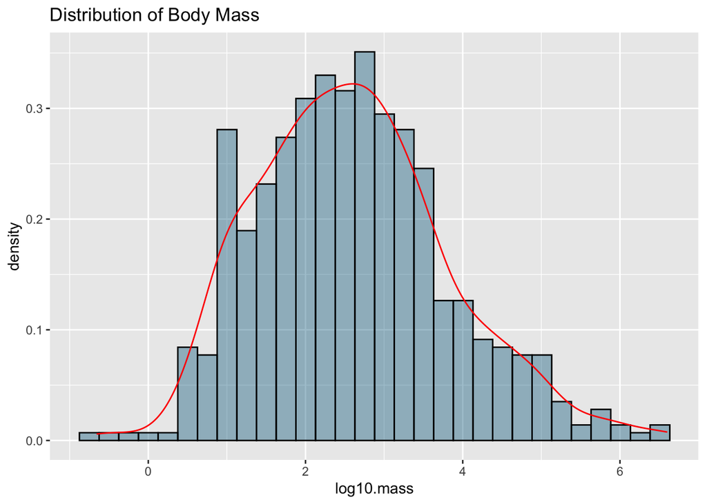

```r
homerange %>%
  ggplot(aes(x=log10.mass)) +
  geom_histogram(aes(y = after_stat(density)), fill = "deepskyblue4", alpha = 0.4, color = "black")+
  geom_density(color = "red")+
  labs(title = "Distribution of Body Mass")
```

## Practice

1. Make a histogram of `log10.hra`. Make sure to add a title.
2. Now plot the same variable using `geom_density()`.
3. Combine them both!

## Practice

1. Use case_when() to make a new column `range_category` that breaks down `log10.hra` into very small, small, medium, and large classes based on quartile.
2. Make a plot that shows how many and which taxonomic classes are represented in each `range_category`.
3. Isolate the small `range_category` and plot the range of `log10.mass` by taxonomic class.

## That’s it! Let’s take a break!

–>[Home](https://jmledford3115.github.io/datascibiol/)